# ENV221

Lecture 1: Module Overview

Peng Zhao

# 1 Overview of the module and R

## 1.1 Learning objectives

In this lecture, you will

1. know the general information of the module,
2. get familiar with the LMO platform,
3. build groups,
4. know what R can do, and
5. set up the R environment.

## 1.2 Module overview

### 1.2.1 Participants

- Module leader
  - Dr. Peng Zhao
  - Websites: Search engine
  - Contact: peng.zhao@xjtlu.edu.cn (preferred), 81889185 (for emergency), WeChat

*[Poll: what should you call me when beginning an email to me?](https://www.mentimeter.com/s/db5eacca954797e4384df95504a1a46e/c62e7cf442b9)*

[figure not shown]

- TAs
  - Xiaoyu Shi (Xiaoyu.Shi18@student.xjtlu.edu.cn)
  - Shanxing Gong (Shanxing.Gong19@student.xjtlu.edu.cn)
- Students
  - ENV: 20
  - BIO: 44

### 1.2.2 Learning platform

- Learning Mall (LMO, [Demo](https://www.learningmall.cn/course/view.php?id=2484))
  - If LMO is down for everyone, use the entry on [BBB](https://bigbluebutton.xjtlu.edu.cn/b/pen-wdq-zwj-huj)(Access code: 894316)
  - If LMO or BBB is fine with most students but you, you can see the recordings of the lectures/practices later. Please send an email to LMO (learningmall@xjtlu.edu.cn) for fixing this issue.
- Assessments
  - Attendance
    - if you have any problem with LMO or BBB or the attendance code, provide some evidence such as a screenshot for the problem and for your attendance, and then your attendance will be recorded manually.
  - Accessible time
  - Submission: 10 or 5 minutes for a quiz + 1 minute for submission. Submit via LMO. Don’t submit via email, except for emergency.
  - How to fill the answer sheet (Quiz 1): Alt+Enter for a line break in Excel.
- XJTLU Email

### 1.2.3 Module handbook

Download from the LMO (Demo):

- Teaching schedule
- Syllabus

### 1.2.4 Previous experiences

Question: How did students perform in this module in previous years and why? How can we improve the situation?

Marks of ENV203 from previous academic years (A. Y.)

| Year | $N$ | $N_\text{failure}$ | $\mu$ | $\sigma$ | min | max |
| --- | --- | --- | --- | --- | --- | --- |
| 2018/2019 | 7 | 4 | 34.6 | 10 | 20 | 50 |
| 2019/2020 | 17 | 9 | 36.5 | 15 | 9 | 58 |
| 2020/2021 | 60 | 3 | 66.5 | 16 | 3 | 91 |
| 2021/2022 | 64 | ? | ? | ? | ? | ? |

Possible reasons for the failures:

1. R has a steep learning curve. Difficult for beginners.

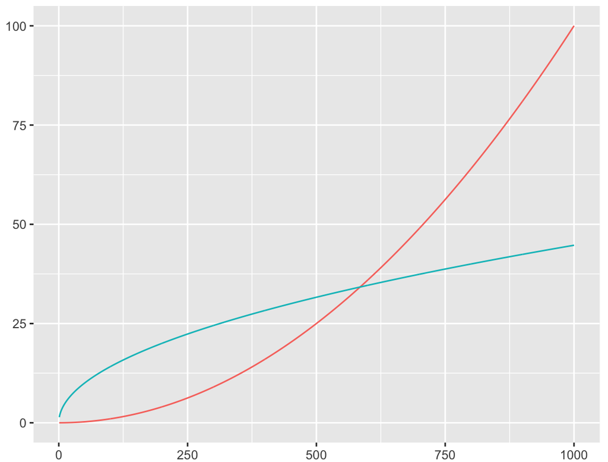

Figure 1.1: Learning curves

2. Lack of engagement in class: Reading materials were not completed; Absent from class.
3. Missing (deadlines for) submissions.

*Question: How can we improve this module?*

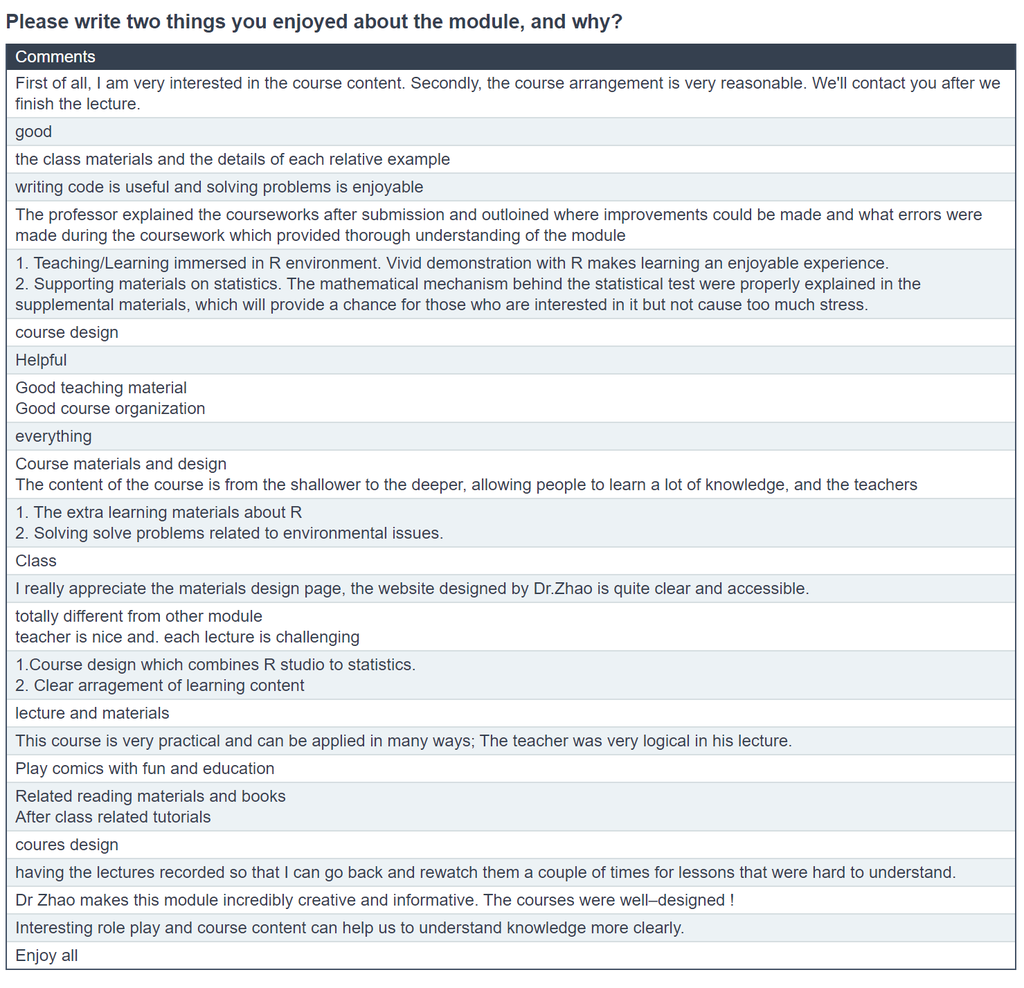

Figure 1.2: MQ: Positive feedback from the previous year.

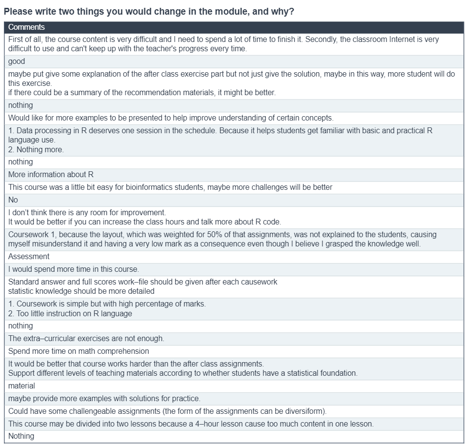

Figure 1.3: MQ: Suggestions from the previous year.

Actions:

1. Intensive learning on R.
2. Finish your work in advance.
3. More exercises, office hours, appointments, etc..
4. On-site exercises. Group work. (Role play.)

*Action: Build Groups*

- 3 or 4 students in a group. Well mixed if possible. Preferably sit close. Remember your group number.
  - (Role play on stage)
  - Group exercises: help each other in your group; present your results
  - Present answers: randomly chosen

*Demonstration: Randomly choose a group.*

```r
sample(1:16, 1)
```

## 1.3 R overview and set-up

### 1.3.1 Tools for statistics

*Poll: What computer software do you often use for statistics or scientific calculation? R, SPSS, Excel, python, MatLab…*

### 1.3.2 What is R

> R is a programming language and free software environment for statistical computing and graphics supported by the R Foundation for Statistical Computing. The R language is widely used among statisticians and data miners for developing statistical software and data analysis. Polls, data mining surveys, and studies of scholarly literature databases show substantial increases in popularity; as of April 2021, R ranks 16th in the TIOBE index, a measure of popularity of programming languages.

> — Wikipedia: *R (programming language)*

In short, R is a language, with which you can talk to your computer.

### 1.3.3 Why R

[figure not shown]

Figure 1.4: R usages

Free, powerful, community-friendly

### 1.3.4 Installation

- Main program (Mandatory)
  - [R](https://www.r-project.org/) (Open with CMD or R GUI)
- Integrated Development Environment (Highly recommended)
  - [RStudio](https://www.rstudio.com/products/rstudio/download/#download)
- Text editors (Recommended)
  - [Notepad++](https://notepad-plus-plus.org/download)
  - [Sublime Text](https://www.sublimetext.com/)
- Online compiler
  - [Coding Ground](https://www.tutorialspoint.com/execute_r_online.php)

### 1.3.5 RStudio

*Demonstration: RStudio interface.*

[figure not shown]

Use hotkeys:

- ctrl + enter (run the line where the cursor is)
- TAB (complete names of functions and objects)
- F1 (get help)
- shift + alt + k (see all shortcuts)

Create an R project:

- File - New project - New directory - New project
- Organize your R scripts and products in a project:
- Save your related files in the project folder
- Always start your work from the .Rproj file

Create a script (.R):

- File - New File - R Script. Hotkey ctrl+shift+N

### 1.3.6 Statistics/calculation with R

- Download the demo dataset `iris.csv` from the LMO.
- Save it in your R project.

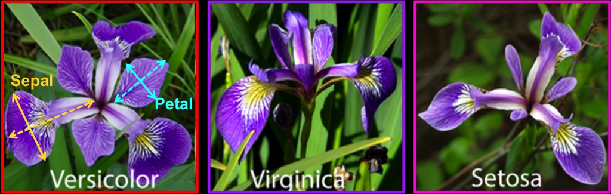

Figure 1.5: Iris

```r
# Import data
iris = read.csv("iris.csv")
iris <- read.csv("iris.csv")

# Simple Calculation
mean(iris$Petal.Length)

# Summarized data
summary(iris)

# ANOVA
myaov <- aov(Sepal.Length ~ Species,
            data = iris)
summary(myaov)

# Insert a column
iris$Sepal.Length.m <- iris$Sepal.Length / 100

# Export data
write.csv(iris, "iris2.csv")
```

### 1.3.7 Graphing with R

```r
# Basic
plot(x = iris$Petal.Width,
     y = iris$Petal.Length)
boxplot(iris$Sepal.Length)

# Install a package
install.packages("ggplot2")
# Load a package
library("ggplot2")
# Use functions
ggplot(iris,aes(Petal.Length, Petal.Width))+
  geom_point()

# Install a package
install.packages("GGally")
# Load a package
library("GGally")
# Use a function
ggpairs(iris[, 2:6])
ggpairs(iris[, 2:6],
        aes(color = Species, alpha = 0.1))
```

Show time:

```r
# Basic
demo(graphics)
demo(persp)
demo(image)
demo(plotmath)

# ggplot2
example(qplot)

# GGally
example(ggpairs)

# MSG (Modern Statistical Graphs)
install.packages("MSG")
library(MSG)
demo(basketball)
demo(pointArts)
```

- [The R Graph Gallery](https://www.r-graph-gallery.com/)

### 1.3.8 Modeling with R

```r
# A linear model
mylm <- lm(iris$Petal.Width ~ iris$Petal.Length)
mylm
summary(mylm)

# Visualization
plot(x = iris$Petal.Length,
     y = iris$Petal.Width)
abline(mylm)

ggplot(iris, aes(Petal.Length,Petal.Width))+
  geom_point() +
  geom_smooth(method = "lm")
```

Show time: [a paper](https://journals.plos.org/plosone/article?id=10.1371/journal.pone.0235247)

```r
# basic
demo(nlm)
demo(lm.glm)
demo(smooth)

library(MSG)
demo(gradArrows1) # Gradient descent method
```

### 1.3.9 Communication with R

R Markdown

- [R Markdown Gallery](https://rmd.pzhao.org)

### 1.3.10 R Commander (Rcmdr)

```r
install.packages("Rcmdr")
library(Rcmdr)
```

- Load data
- Calculation
- Graphs
- Communication

## 1.4 Further readings

- *A Beginner’s Guide to R*, Chapter 1
- *A (very) short introduction to R*

## 1.5 Exercises

### 1.5.1 Set up

- Install R and RStudio.
- Create a project with RStudio.
- Open the project, and create a script file.

### 1.5.2 Air Quality

The New York Air Quality dataset shows daily air quality measurements in New York, May to September 1973. The measurements include mean ozone in parts per billion from 1300 to 1500 hours at Roosevelt Island, solar radiation in Langleys in the frequency band 4000–7700 Angstroms from 0800 to 1200 hours at Central Park, average wind speed in miles per hour at 0700 and 1000 hours at LaGuardia Airport, maximum daily temperature in degrees Fahrenheit at La Guardia Airport.

- Download the data file *airquality.csv* from LMO.
- Import it into R as a data frame.
- Summarize the dataset.
- Make a scatter plot with two numeric variables, and add a linear fitted line.

### 1.5.3 ENV221 Students

The ENV221 Students dataset shows the survey data about these students.

- Download the data files *students_env221.csv* from LMO.
- Import it into R as a data frame.
- Summarize the dataset.
- Make a scatter plot with two numeric variables, and add a linear fitted line.